# Practicals — Introduction to Bayesian analysis for medical studies

Boris Hejblum

May 13<sup>th</sup> 2019

# Exercise 1: Monte Carlo

1. Create a Monte Carlo sample of size $50$ from a Gaussian distribution with mean $m=2$ and standard deviation $s=3$. Compute Monte Carlo estimates of both the mean and the standarddeviation on this $50$-sample. Then create a sample of size $20\,000$ and compute again such estimates on this $20\,000$-sample. What do you notice ? Which famous theoretical property is illustrated here ?
2. Let’s now program an estimate of $\pi\approx 3,1416$
   1. Program a function `roulette_coord` which has only one argument `ngrid` (representing the number of different outcomes possible on the *roulette* used) whose default is `35`, generating the two coordinates of a point (between $0$ and $35$) as a vector. Use the `R` function `sample` (whhose help page is accessible through the command `?sample`). The function will return the vector of the 2 coordinates `x` and `y` generated this way.
   2. Thanks to the formula to compute the distance bewteen 2 points: $d = \sqrt{(x_1 - x_2)^2 + (y_1 - y_2)^2}$, program a function computing the distance to the origin (here has coordinates $(\frac{ngrid}{2}, \frac{ngrid}{2})$) that checks if the computed distance is less than the unit disk radius ($R = \frac{ngrid}{2}$). This function, called for instance `inside_disk_fun()`, will have 2 arguments: the vector `p` containing the coordinates of the points on the one hand, and the integer `ngrid` on the other hand. It will return a boolean value (`TRUE`or `FALSE`) indicating the point is inside the disk.
   3. The surface ratio between the disk (radius $\frac{ngrid}{2}$) and the square (side length $ngrid$) is equal to $\frac{\pi}{4}$, i.e. the probability of sampling a point the disk rather than outside is $\frac{\pi}{4}$. Now, using this result, program a function to compute a Monte Carlo estimate of $pi$ from a boolean vector of size $n$ (the number of sampled points), which is `TRUE` if the point is indeed inside the disk and `FALSE` otherwise.
   4. Using the code below, generate 200 points and plot the data generated. What is the corresponding Monte Carlo estimate of $\pi$ ? Change `npoints` and comment. How could the estimation be improved (ProTip: try `ngrid <- 1000` and `npoints <- 5000`?

      ```r
      # Grid size (resolution)
      ngrid <- 35

      # Monte Carlo sample size
      npoints <- 200

      # Points generation
      pp <- matrix(NA, ncol = 2, nrow = npoints)
      for (i in 1:nrow(pp)) {
          pp[i, ] <- roulette_coord(ngrid)
      }

      # Estimate pi
      in_disk <- apply(X = pp, MARGIN = 1, FUN = inside_disk, ngrid = ngrid)
      piMC(in_disk)
      ```

      ```
      ## [1] 3.06
      ```

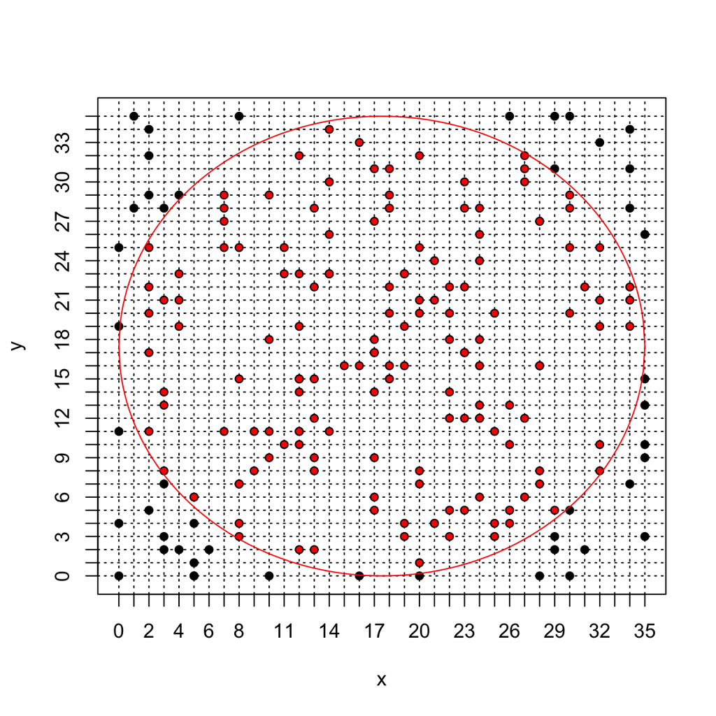

      ```r
      # Plot first we initialise an empty plot with the right size using argument
      plot(x = pp[, 1], y = pp[, 2], xlim = c(0, ngrid), ylim = c(0, ngrid), axes = 0,
          xlab = "x", ylab = "y", type = "n")
      ## we tick the x and then y axes from 1 to ngrid
      axis(1, at = c(0:ngrid))
      axis(2, at = c(0:ngrid))
      ## we add a square around the plot
      box()
      ## we plot the grid (using dotted lines thanks to the argument `lty = 3`)
      ## onto which the points are sample
      for (i in 0:ngrid) {
          abline(h = i, lty = 3)
          abline(v = i, lty = 3)
      }
      ## we add the sampled points
      lines(x = pp[, 1], y = pp[, 2], xlim = c(0, ngrid), ylim = c(0, ngrid), xlab = "x",
          ylab = "y", type = "p", pch = 16)
      ## we add the circle display
      x.cercle <- seq(0, ngrid, by = 0.1)
      y.cercle <- sqrt((ngrid/2)^2 - (x.cercle - ngrid/2)^2)
      lines(x.cercle, y = y.cercle + ngrid/2, col = "red")
      lines(x.cercle, y = -y.cercle + ngrid/2, col = "red")
      ## finally we color in red the points sampled inside the disk
      lines(x = pp[in_disk, 1], y = pp[in_disk, 2], xlim = c(0, ngrid), ylim = c(0,
          ngrid), xlab = "x", ylab = "y", type = "p", pch = 16, col = "red", cex = 0.7)
      ```

# Exercise 2: Inverse transform sampling

Program a sampling algorithm to sample from the exponential distribution with parameter $\lambda$ thanks to the inverse transform function (starting from the `R` function `runif`). Compare your results to the built-in `R` function `rexp` by comparing their histogram or density (e.g. by using the functions `density()`, `plot()` and `lines()`). Try out several values for the $\lambda$ parameter of the exponential distribution (e.g. 1, 10, 0.78, …).

# Exercise 3: Metropolis-Hastings algorithm(s) for the historical application (Beta-Bernoulli model)

Using the historical example, program an independant Metropolis-Hastings algorithm to estimate the *posterior* distribution of parameter$\theta$ (i.e. the probability of having a girl for a birth). The *prior* distribution on $\theta$ will be used as the instrumental proposal, and we will start by using a uniform *prior* on $\theta$. We will consider the $493,472$ births observed in Parisbetween 1745 and 1770, of which $241,945$ were girls.

1. Program a function that computes the numerator of the *posterior* density, which can be written $p(\theta|n,S)\propto\theta^S(1-\theta)^{n-S}$ with $S = 241\,945$ and $n = 493\,472$ (plan for a boolean argument that will allow to return — or not — the logarithm of the *posterior* instead).
2. Program the corresponding Metropolis-Hastings algorithm, returning a vector of size $n$ sampled according to the *posterior* distribution. Also returns the vector of acceptance probabilities $\alpha$. What happens if this acceptance probability is *NOT* computed on the $log$ scale ?
3. Compare the *posterior* density obtained with this Metropolis-Hastings algorithm over 2000 itérations to the theoretical one (the theoretical density can be obtained with the `R` fuction `dbeta(x, 241945 + 1, 251527 + 1)` and represented with the `R` function `curve(..., from = 0, to = 1, n = 10000)`). Mindfully discard the first 500 iterations of your Metropolis-Hastings algorithm in order to reach the Markov chain convergence before constructing your Monte Carlo sample. Comment those results, especially in light of the acceptance probabilities computed throughout the algorithm, as well as the different sampled values for $\theta$.
4. Now imagine we only observe $100$ births, among which $49$ girls, and use a $\text{Beta}(\alpha = 3, \beta=3)$ distribution as *prior*. Program the corresponding M-H algorithm and study the new results (one can do $10,000$ iterations of this new M-H algorithm for instance, again mindfully discarding the first 500 iterations).
5. Using the data from the historical example and with a $\text{Beta}(\alpha = 3, \beta=3)$ *prior*, program a random-walk Metropolis-Hastings algorithm (with a Gaussian random step with a standard deviation of $0.02$ for instance). Once again, study the results obtained this way (one can change the size of the random step).

# Exercise 4: Introduction to `BUGS` & `JAGS`

The [BUGS project](https://www.mrc-bsu.cam.ac.uk/software/bugs/) (*Bayesian inference Using Gibbs Sampling*) was initiated in 1989 by the MRC (*Medical Research Council*) Biostatistical Unit at the University of Cambridge (United-Kingdom) to develop a flexible and user-friendly software for Bayesian analysis of complex models through MCMC algorithms. Its most famous and original implementation is `WinBUGS`, a clicking software available under *Windows*. `OpenBUGS` is an alternative implementation of `WinBUGS` running on either *Windows*, *Mac OS* ou *Linux*. [`JAGS`](http://mcmc-jags.sourceforge.net/) (*Just another Gibbs Sampler*) is a different and newer implementation that also relies on the `BUGS` language. Finally, the [`STAN`](http://mc-stan.org/) software must also be mentionned, recently developed et the Columbia Univeristy, ressemble `BUGS` through its interface, but relies on innovative MCMC approaches, such as Hamiltonian Monte Carlo, or variational Bayes approaches. A very useful resource is the [JAGS user manual](http://sourceforge.net/projects/mcmc-jags/files/Manuals/3.x/jags_user_manual.pdf).

To familiarise yourself with `JAGS` (and its `R` interface through the package `rjags`), we will look here at the *posterior* estimation of the mean and variance of observed data that we will model with a Gaussian distribution.

0. load the `R` package `rjags`.

   ```r
   library(rjags)
   ```

A `BUGS` model has 3 components:

- *the model*: specified in an external text file (`.txt`) according to a specific `BUGS` syntax
- *the data*: a list containing each observation under a name matching the one used in the model specification
- *the initial values*: (optional) a list containing the initial values for the various parameters to be estimated
1. Sample $N=50$ observations from a Gaussian distribution with mean $m = 2$ and standard deviation $s = 3$ using the `R` function `rnorm`.
2. Read the help of the `rjags` package, then save a text file (`.txt`) the following code defining the `BUGS` model:

   ```
   # Model
   model{

     # Likelihood
     for (i in 1:N){
       obs[i]~dnorm(mu,tau)
     }

     # Prior
     mu~dnorm(0,0.0001) # proper but very flat (weakly informative)
     tau~dgamma(0.0001,0.0001) # proper but very flat (weakly informative)

     # Variables of interest
     sigma <- pow(tau, -0.5)
   }
   ```

Each model specification file must start with the instruction `model{` indicating `JAGS` it is about to recieve a model specification. Then the model must be set up, usually by cycling along the data with a `for` loop. Here, we want to declare `N` observations, and each of them `obs[i]` follows a Gaussian distribution (characterized with the command `dnorm`) of mean `mu` and precision `tau`. *Warning*: in `BUGS`, the Gaussian distribution is parametrized by its precision, which is simply the inverse of the variance ($\tau = 1/\sigma^2$). Then, one needs to define the *prior* distribution for each parameter, here both `mu` and `tau`. For `mu`, we use a Gaussian *prior* with mean $0$ and precision $10^{-4}$ (thus variance $10,000$: this corresponds correspond to a weakly informative *prior* and quite spread out given the sale of our data. For `tau` we use the conjugate *prior* for precision in a Gaussian model, namely the Gamma distribution (with vely small parameters, here again to remain the less informative possible). Finally, we give a deterministic definition of the additional parameters of interest, here the standard deviation `sigma`.

3. With the `R` function `jags.model`, create a `jags` object `R`.
4. With the `R` function `coda.samples()`, generate a sample of size $2,000$ from the *posterior* distibutions for the mean and standard deviation parameters de moyenne et de variance.
5. Study the output of the `coda.samples()` `R` function, and compute both the *posterior* mean and median estimates for `mu` and `sigma`. Give a credibility interval at 95% for both.
6. Load the `coda` `R` package. This package functions for convergence diagnostic and analysis of MCMC algorithm outputs.

   ```r
   library(coda)
   ```

7. To diagnose the convergence of an MCMC algorithm, it is necessary to generate different Markov chains, with different initial values. Recreate a new `jags` object in `R` and specify 3 the use of 3 Markov chains with the argument `n.chains`, and initialize `mu` and `tau` at $0, -10, 100$ and at $1, 0.01, 0.1$ respectively with the argument `inits` (**ProTip:** use a `list` of `list`, one for each chain). Comment.
8. With the `R` function `gelman.plot()`, plot the Gelman-Rubin statistic.
9. With the `R` functions `autocorr.plot()` and `acfplot()` evaluate the autocorrélation of the studied parameters.
10. With the `R` function `cumuplot()` evaluate the running quantiles of the studied parameters. How can you interpret them ?
11. With the `R` function `crosscorr.plot()` evaluate the correlations between the studied parameters. How can you interpret them ?
12. With the function `hdi()` from the `R` package `HDInterval`, provide highest densitity *posterior* credibility intervals at 95%, and compare them to those obtained with the $2.5$% and $97.5$% quantiles.

# Exercise 5: *Post-mortem* analysis of an under-powered randomized trial

The randomized clinical trial *EOLIA* (Combes et al. 2018) evaluated a new treatment for severe acute respiratory distress syndrome (ARDS) by comparing the mortality rate after 60 days among 249 patients randomized between a control group (receiving conventional treatmetn, i.e. mechanical ventilation) and a treatment group receiving extracorporeal membrane oxygenation (ECMO) — the new treatment studied. A frequentist analysis of the data concluded to a Relative Risk of death of 0.76 in the ECMO compared to control (in Intention to Treat), with $CI_{95\%} = [0.55 , 1.04]$ and the associated p-value of $0.09$.

(Goligher et al. 2018) performed a Bayesian re-analysis of these data, further exploring the evidence and how it can be quantified and summarized with a Bayesian approach.

1. Write the mathematical model used by (Goligher et al. 2018)
2. Write the corresponding BUGS model

Observed data from the *EOLIA* trial

[output not shown]

3. First create two binary data vectors `ycontrol` and `yecmo`, that are either `1` or `0`, to encode the observations from the data table above. Then uses the `jags.model()` and `coda.samples()` to replicate the estimation from (Goligher et al. 2018) (**ProTip:** use the function `window()` to remove the burn-in observation from the output of the `coda.samples` funtion.)
4. Check the convergence, and then comment the estimate results (**ProTip:** look at the effective sample size with the `effectiveSize()` `R` function).
5. Change to a more informative *prior* using a Gaussian distribution for the log(RR), centered on log(0.78) and with a standard deviation of 0.15 in the log(RR) scale (i.e. a precision of $\approx 45$). Comment the results. Try out other *prior* distributions.

# Exercise 6: Bayesian meta-analysis

In 2014, Crins *et al.* published a meta-analysis assessing the incidence of acute rejection (AR) with or without Interleukin-2 receptor antagonists. In this exercise we will recreate this analysis.

0. Load the `R` package `bayesmeta` (Röver 2017) and the data from (Crins et al. 2014) with the `R` command `data("CrinsEtAl2014")`.

   ```r
   library(bayesmeta)
   data(CrinsEtAl2014)
   ```

1. Play around with the companion shiny app at: http://ams.med.uni-goettingen.de:3838/bayesmeta/app/. Explore and comment the results and the outputs, try out different options and priors, etc.
2. Within `R` now, using the `escalc()` function from the package `metafor`, compute the estimated *log odds ratios* from the 6 considered studies alongside their sampling variances (**ProTip:** read the *Measures for Dichotomous Variables* section from the help of the `escalc()` function). Check that those are the same as the one on the online *shiny app* (**ProTip:** ‘sigma’ is the stantard error, i.e. the square root of the sampling variance `vi`)

   ```r
   library("metafor")
   crins.es <- escalc(measure = "OR", ai = exp.AR.events, n1i = exp.total, ci = cont.AR.events,
       n2i = cont.total, slab = publication, data = CrinsEtAl2014)
   crins.es[, c("publication", "yi", "vi")]
   ```

   Log odds ratios are symmetric around zero and have a sampling distributions closer to the normal distibution than the natural OR scale. They are usually prefered for meta-analyses. Their sample variance is computed as the sum of the inverse of all the counts in the $2 \times 2$ associated contingency table (Fleiss and Berlin 2009).
3. Perform a random-effect meta-analysis of those data using the `bayesmeta()` function from the `R` package `bayesmeta`, within `R`. Use a uniform prior on $[0,4]$ for $\tau$ and a Gaussain prior for $\mu$ centered around 0 and with a standard deviation of 4.
4. Write the corresponding random-effects Bayesian meta-analysis model.
5. Use `rjags` to estimate the same model.

# Exercise 7: how NOT to report a CRM trial

In this exercise, we will first do a critical reading of the article from (Kaguelidou et al. 2016).

1. List the method elements that are missing from this aticle.
2. Read and discuss Table 3.
3. Load the `R` package `bcrm` and conduct an imaginary CRM trial interactive with the following code lines:

   ```r
   library(bcrm)
   sdose <- c(1, 1.5, 2, 2.5, 3)
   dose.label <- c(5, 10, 15, 25, 40, 50, 60)
   bcrm(stop = list(nmax = 42), p.tox0 = p.tox0, dose = dose.label, ff = "power",
       prior.alpha = list(1, 1, 1), target.tox = 0.3, start = 1)
   ```

# Bibliography

Combes, Alain, David Hajage, Gilles Capellier, Alexandre Demoule, Sylvain Lavoué, Christophe Guervilly, Daniel Da Silva, et al. 2018. “Extracorporeal Membrane Oxygenation for Severe Acute Respiratory Distress Syndrome.” *New England Journal of Medicine* 378 (21): 1965–75. https://doi.org/10.1056/NEJMoa1800385.

Crins, Nicola D., Christian Röver, Armin D. Goralczyk, and Tim Friede. 2014. “Interleukin-2 Receptor Antagonists for Pediatric Liver Transplant Recipients: A Systematic Review and Meta-Analysis of Controlled Studies.” *Pediatric Transplantation* 18 (8): 839–50. https://doi.org/10.1111/petr.12362.

Fleiss, Joseph L., and Jesse A. Berlin. 2009. “Effect Sizes for Dichotomous Data.” In *The Handbook of Research Synthesis and Meta-Analysis, 2nd Ed*, 237–53. New York, NY, US: Russell Sage Foundation.

Goligher, Ewan C., George Tomlinson, David Hajage, Duminda N. Wijeysundera, Eddy Fan, Peter Jüni, Daniel Brodie, Arthur S. Slutsky, and Alain Combes. 2018. “Extracorporeal Membrane Oxygenation for Severe Acute Respiratory Distress Syndrome and Posterior Probability of Mortality Benefit in a Post Hoc Bayesian Analysis of a Randomized Clinical Trial.” *JAMA* 320 (21): 2251. https://doi.org/10.1001/jama.2018.14276.

Kaguelidou, Florentia, Corinne Alberti, Valerie Biran, Olivier Bourdon, Caroline Farnoux, Sarah Zohar, and Evelyne Jacqz-Aigrain. 2016. “Dose-Finding Study of Omeprazole on Gastric pH in Neonates with Gastro-Esophageal Acid Reflux Using a Bayesian Sequential Approach.” Edited by Imti Choonara. *PLOS ONE* 11 (12): e0166207. https://doi.org/10.1371/journal.pone.0166207.

Röver, Christian. 2017. “Bayesian Random-Effects Meta-Analysis Using the Bayesmeta R Package.” *arXiv Preprint 1711.08683*. http://www.arxiv.org/abs/1711.08683.